# Using the Jupyter Notebook in a Mathematica-like way

### Setting up Jupyter Notebook

This setup uses the IPython kernel, but Jupyter Notebook can be used to run a number of different kernels like R. The easiest way to set up your computer to run Jupyter for this purpose is to download and install Anaconda. However, if you need to set up Jupyter from the base Python installation, you will have to install the following modules:

- Jupyter
- scipy modules:
  - ipython
  - sympy
  - numpy
  - matplotlib
  - pandas

You can do so using the "pip install " command from the command prompt (Windows) or terminal (Linux) once you have Python installed.

Jupyter Notebooks (.ipynb) can be saved to a github repository and viewed online using nbviewer: https://nbviewer.jupyter.org/

Jupyter Notebooks can also be exported to formats such as HTML and posted as a webpage, however, I've yet to get .pdf exporting to work.

## Imports and Definitions

The following code needs to be run in order to load the necessary functions into the namespace.

```python
%reset -f #Resets variable definitions without having to restart kernel

#Select a method of plotting by modifying the matplotlib backend:
#This allows matplotlib pyplots to appear inline:
%matplotlib inline
#This allows matplotlib pyplots to appear in a Qt4 Window, with some options to modify the graph:
#import matplotlib
#matplotlib.use('Qt4Agg')

from matplotlib import pyplot as plt #Plotting package (matplotlib plotting will require calls to plt methods)

from sympy import * #Symbolic Math package (You can also use NumPy, but SymPy allows LaTeX style printing)
from sympy.plotting import * #SymPy's plotting package
x, y, z = symbols('x y z')
#f, g, h = symbols('f g h', cls=Function)
k, m, n = symbols('k m n', Integer = true)
init_printing(use_latex = 'mathjax') #Enables LaTeX printing
```

[output not shown]

## Math

Some Symbolic math examples using SymPy. Unfortuantely, it looks like you are only able to print one symbolic math output per cell.

```python
x_1 = symbols('x_1')
f = x**2 + 5*x + cos(x) + atan(x) + tanh(x) + x_1
f
```

$$x^{2} + 5 x + x_{1} + \cos{\left (x \right )} + \tanh{\left (x \right )} + \operatorname{atan}{\left (x \right )}$$

```python
g = diff(f,x)
g
```

$$2 x - \sin{\left (x \right )} - \tanh^{2}{\left (x \right )} + 6 + \frac{1}{x^{2} + 1}$$

```python
h = Function('h')
F = Eq(h(x).diff(x)+h(x), sin(x))
F
```

$$h{\left (x \right )} + \frac{d}{d x} h{\left (x \right )} = \sin{\left (x \right )}$$

```python
dsolve(F, h(x))
```

$$h{\left (x \right )} = \left(C_{1} + \frac{e^{x}}{2} \sin{\left (x \right )} - \frac{e^{x}}{2} \cos{\left (x \right )}\right) e^{- x}$$

```python
array = [[j*10+i for i in range(1,10)] for j in range(1,10)]
print array
Matrix(array)
```

```
[[11, 12, 13, 14, 15, 16, 17, 18, 19], [21, 22, 23, 24, 25, 26, 27, 28, 29], [31, 32, 33, 34, 35, 36, 37, 38, 39], [41, 42, 43, 44, 45, 46, 47, 48, 49], [51, 52, 53, 54, 55, 56, 57, 58, 59], [61, 62, 63, 64, 65, 66, 67, 68, 69], [71, 72, 73, 74, 75, 76, 77, 78, 79], [81, 82, 83, 84, 85, 86, 87, 88, …
```

$$\left[\begin{matrix}11 & 12 & 13 & 14 & 15 & 16 & 17 & 18 & 19\\21 & 22 & 23 & 24 & 25 & 26 & 27 & 28 & 29\\31 & 32 & 33 & 34 & 35 & 36 & 37 & 38 & 39\\41 & 42 & 43 & 44 & 45 & 46 & 47 & 48 & 49\\51 & 52 & 53 & 54 & 55 & 56 & 57 & 58 & 59\\61 & 62 & 63 & 64 & 65 & 66 & 67 & 68 & 69\\71 & 72 & 73 & 74 & 75 & 76 & 77 & 78 & 79\\81 & 82 & 83 & 84 & 85 & 86 & 87 & 88 & 89\\91 & 92 & 93 & 94 & 95 & 96 & 97 & 98 & 99\end{matrix}\right]$$

## Data

Generating a mock data set. You can use this method (with high enough resolution) to generate theoretical curves. With real data, you would use Pandas or NumPy to load float arrays into the kernel.

```python
xmin = 0
xmax = 10
xstep = 0.25 #Determines distance between adjacent points and hence the resolution of the graph array
dat1 = [i*xstep+xmin for i in range(int(xmax/xstep))]
dat2 = [40*sin(i) for i in dat1]
dat3 = [i**2 for i in dat1]
```

## Plotting

The first plot is of the mock data plotted using matplotlib. The latter plot are of SymPy functions using the SymPy plotting tools.

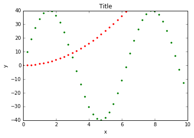

```python
plt.title("Title")
plt.xlabel("x")
plt.ylabel("y")
plt.xlim(0,10)
plt.ylim(-40,40)
plt.plot(dat1, dat2, 'g.')
plt.plot(dat1, dat3, 'r.')
```

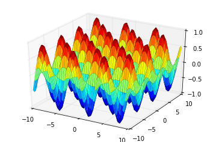

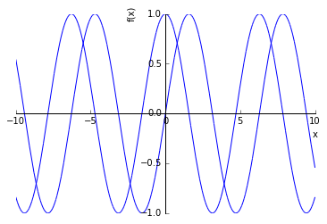

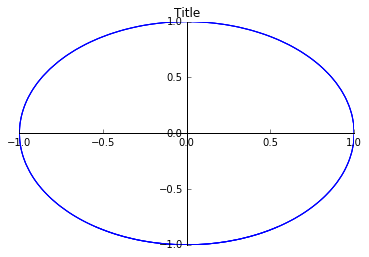

```
{'_backend': <sympy.plotting.plot.MatplotlibBackend at 0xc192668>,
 '_series': [<sympy.plotting.plot.Parametric2DLineSeries at 0xc192518>],
 'aspect_ratio': 'auto',
 'autoscale': True,
 'axis': True,
 'axis_center': 'auto',
 'backend': sympy.plotting.plot.DefaultBackend,
 'legend': False,
 'margin': 0,
 'title': 'Title',
 'xlabel': None,
 'xlim': None,
 'xscale': 'linear',
 'ylabel': None,
 'ylim': None,
 'yscale': 'linear'}
```

```python
p1 = plot3d(sin(x)*cos(y))
p2 = plot(sin(x),cos(x))
p3 = plot_parametric((sin(x),cos(x)),title="Title")
p3.__dict__
```